# Лабораторная работа №10

Расширенные настройки SMTP-сервера

Агаева Зейнаб Фуад кызы

1032245473@rudn.ru

Российский университет дружбы народов

2026-10-24

# Цели и задачи работы

## Цель лабораторной работы

Получить практические навыки расширенной настройки почтового сервера `Postfix` и `Dovecot`, организации доставки электронной почты по протоколу `LMTP`, настройки SMTP-аутентификации с использованием `SASL`, обеспечения защищённой передачи сообщений через `TLS`, проверки работы почтовых служб и автоматизации настроек средствами `Vagrant`.

# Процесс выполнения лабораторной работы

## Добавляю протокол LMTP в конфигурацию Dovecot

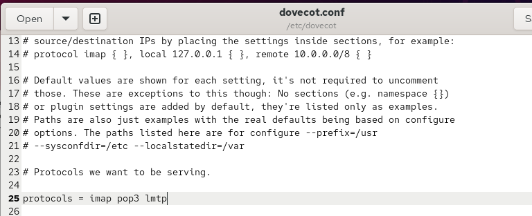

Добавление протокола LMTP в конфигурацию Dovecot

## Настраиваю службу LMTP и Unix-сокет для Postfix

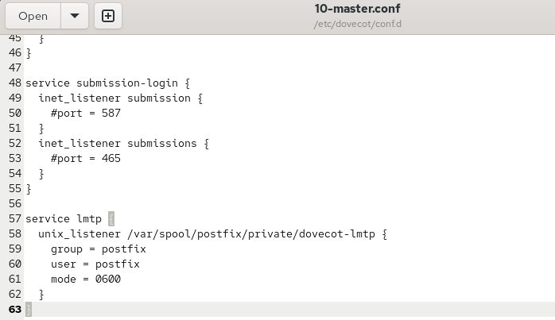

Настройка службы LMTP и Unix-сокета для взаимодействия с Postfix

## Настраиваю формат имени пользователя в Dovecot

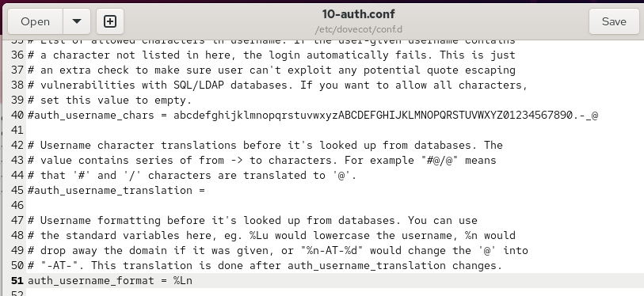

Настройка формата имени пользователя для аутентификации Dovecot

## Настраиваю передачу почты через LMTP и перезапускаю службы

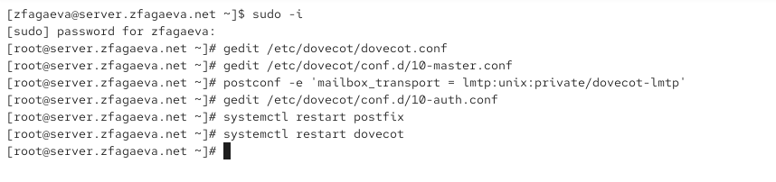

Настройка передачи почты через LMTP и перезапуск почтовых служб

## Отправляю тестовое письмо для проверки LMTP

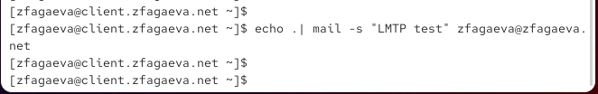

Отправка тестового почтового сообщения для проверки LMTP

## Проверяю доставку сообщения в журнале почтового сервера

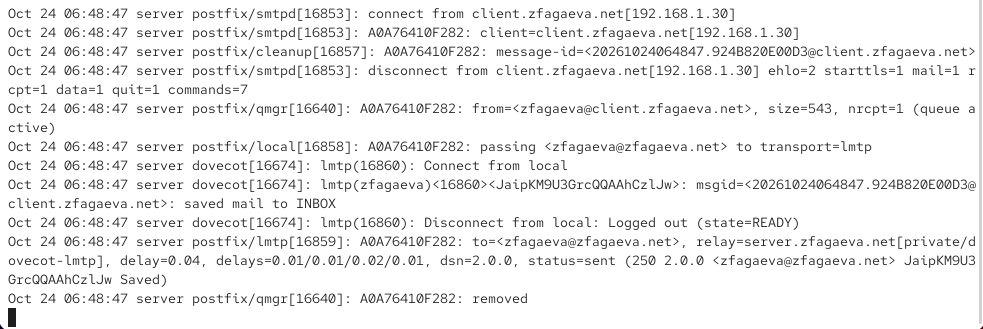

Проверка журнала почтовой службы и успешной доставки сообщения по LMTP

## Проверяю получение тестового письма в почтовом ящике

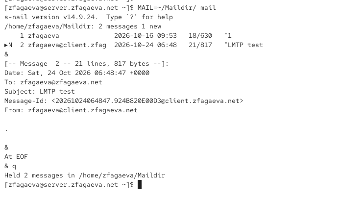

Проверка получения тестового письма в почтовом ящике пользователя

## Настраиваю службу SASL-аутентификации Dovecot

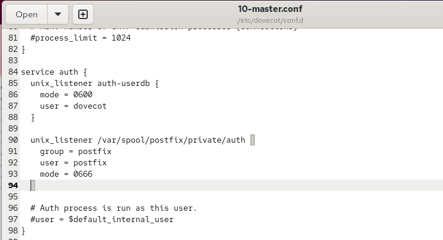

Настройка службы аутентификации Dovecot и прав доступа к Unix-сокетам

## Настраиваю SMTP-аутентификацию в файле master.cf

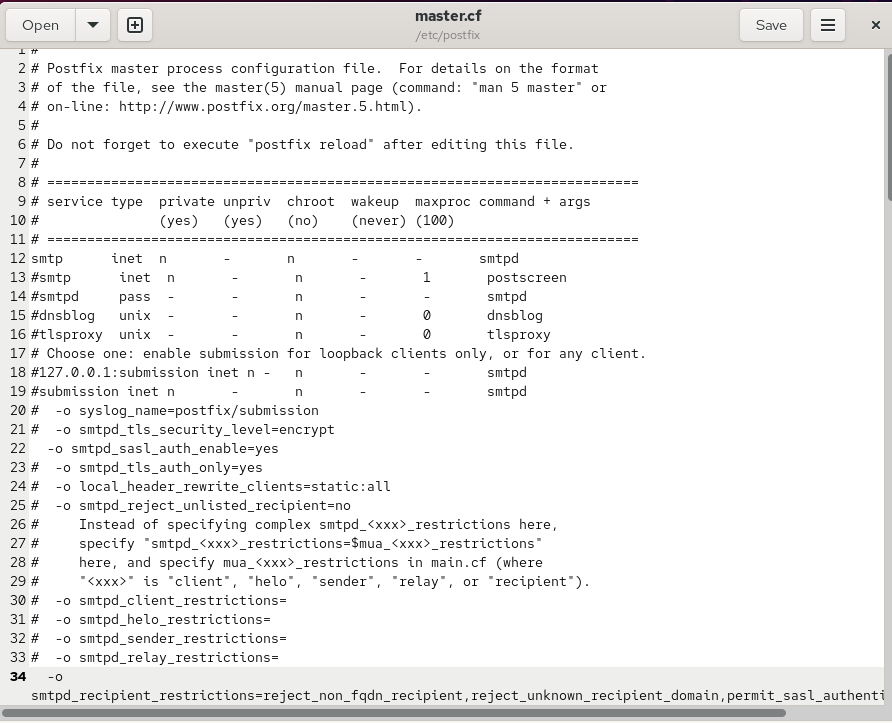

Редактирование конфигурации SMTP-службы в файле master.cf

## Настраиваю SASL и ограничения пересылки почты в Postfix

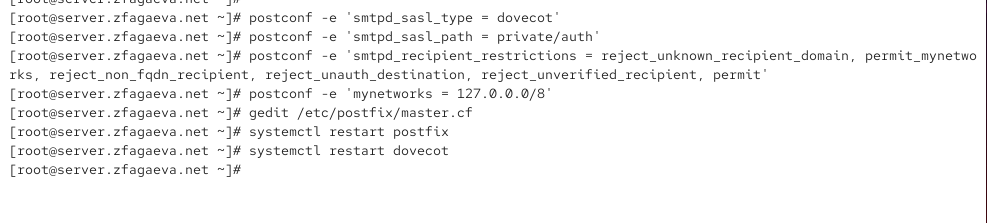

Настройка SASL-аутентификации и ограничений SMTP в Postfix

## Проверяю SMTP-аутентификацию через Telnet

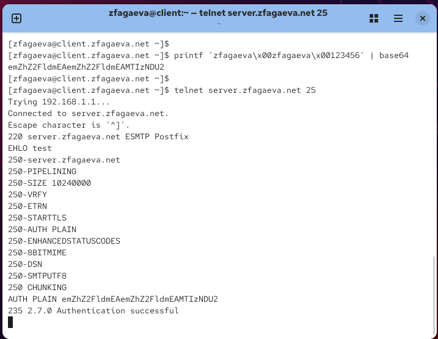

Проверка SMTP-аутентификации через Telnet на порту 25

## Настраиваю сертификат и параметры TLS в Postfix

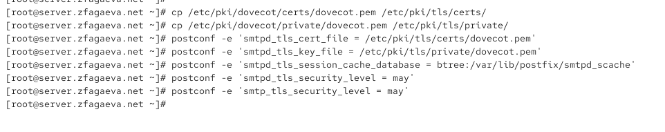

Настройка сертификата и параметров TLS в Postfix

## Настраиваю службу SMTP Submission на порту 587

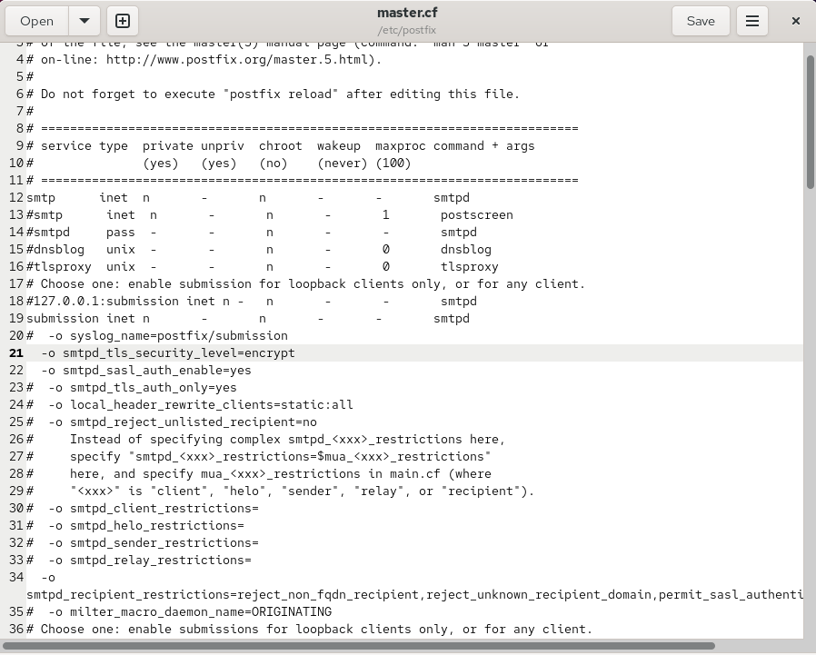

Настройка службы SMTP Submission на порту 587

## Разрешаю SMTP Submission в FirewallD и перезапускаю Postfix

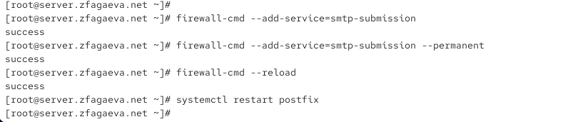

Разрешение службы SMTP Submission в межсетевом экране и перезапуск Postfix

## Проверяю защищённое SMTP-соединение через OpenSSL

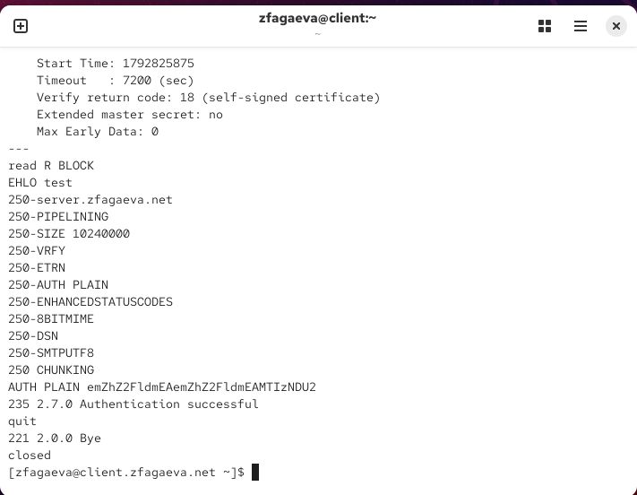

Проверка защищённого SMTP-соединения и аутентификации через OpenSSL

## Настраиваю SMTP с STARTTLS в почтовом клиенте Evolution

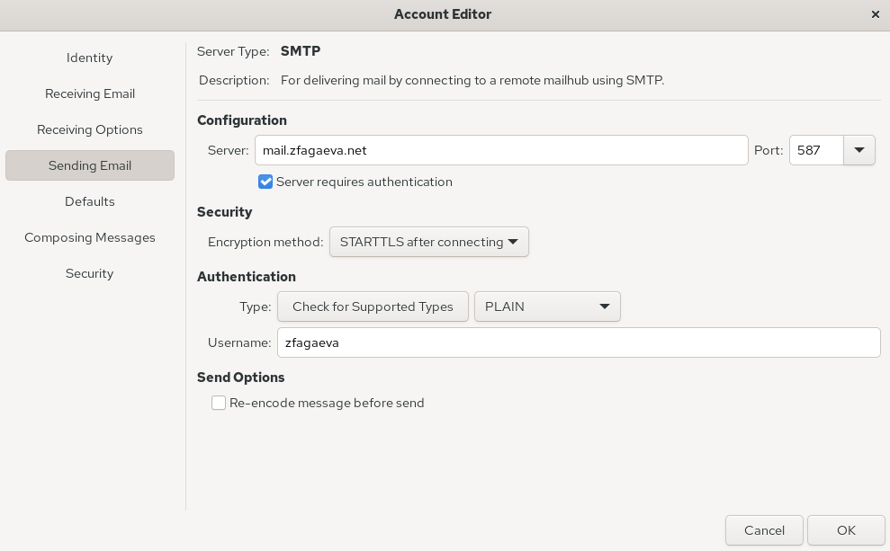

Настройка SMTP-сервера с STARTTLS и аутентификацией в Evolution

## Проверяю отправку и получение тестовых писем в Evolution

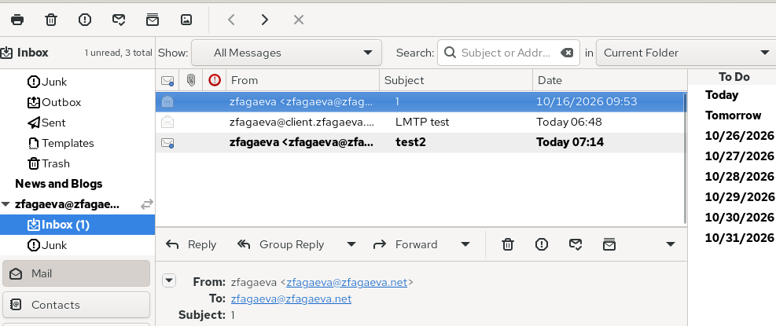

Проверка получения тестовых сообщений в почтовом клиенте Evolution

## Проверяю доставку сообщений через STARTTLS в журнале Postfix

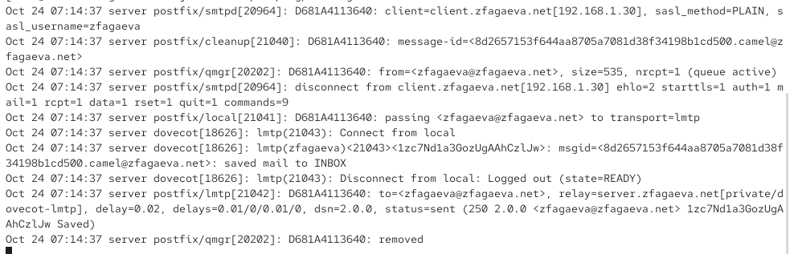

Анализ журнала Postfix и Dovecot после отправки письма через STARTTLS

## Изменяю скрипт автоматической настройки почтового сервера

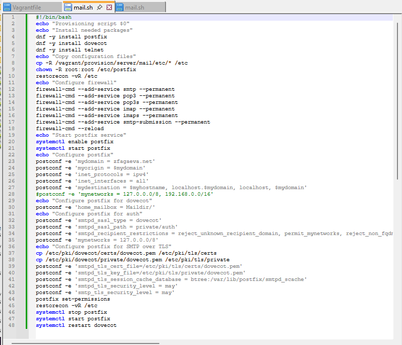

Корректировка скрипта автоматической настройки почтового сервера в Vagrant

## Изменяю скрипт автоматической настройки почтового клиента

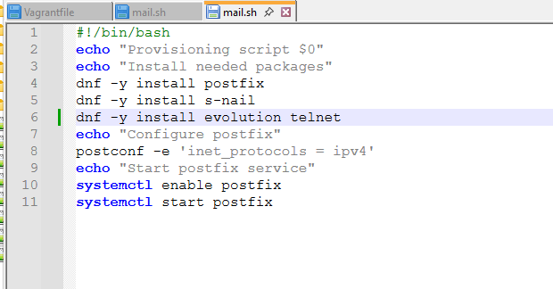

Корректировка скрипта автоматической настройки почтового клиента в Vagrant

# Выводы по проделанной работе

## Вывод

В ходе лабораторной работы была выполнена расширенная настройка почтового сервера `Postfix` и `Dovecot` на виртуальной машине `server`. Настроена доставка электронной почты по протоколу `LMTP` через Unix-сокет `/var/spool/postfix/private/dovecot-lmtp`. Успешная доставка тестового письма подтверждена содержимым почтового ящика и журналом `/var/log/maillog`.

Для SMTP-сервера настроена аутентификация пользователей через `SASL` с использованием Dovecot. Установлены ограничения на приём и пересылку сообщений для предотвращения несанкционированного использования сервера в качестве открытого Relay-сервера. Работа аутентификации проверена через `Telnet` на порту `25`.

Настроено шифрование SMTP-соединений с использованием `TLS` и сертификата Dovecot. Для защищённой отправки почты настроена служба `SMTP Submission` на порту `587`, а в межсетевом экране `FirewallD` разрешена служба `smtp-submission`. Работа защищённого соединения и SASL-аутентификации проверена с помощью `OpenSSL`.

На виртуальной машине `client` настроен почтовый клиент `Evolution` для отправки сообщений через `SMTP` с использованием `STARTTLS` и аутентификации `PLAIN`. Успешная отправка и получение тестовых писем подтверждены содержимым почтового ящика и записями в журнале почтового сервера.